# Aula 7 - Econometria de Séries Temporais

João Ricardo F. de Lima

23 de março de 2022.

# 1 Co-Integração

A regressão de uma série temporal não estacionária contra outra série temporal não estacionária pode produzir uma regressão espúria, também chamada de regressão sem sentido;

Contudo, existe uma exceção a essa regra. Considere duas séries não estacionárias e integradas de mesma ordem, $Y_t$ e $X_t$ e uma relação linear entre elas dada por

$$Y_t=\beta X_t + \epsilon_t$$

Se existir algum valor de $\beta$ tal que $Y_t-\beta X_t$ seja I(0), mesmo com as séries originais não sendo estacionárias, a regressão é considerada não espúria.

Neste caso, as séries são ditas cointegradas e compartilham a mesma tendência. Dito de outra forma, o que se obteve foi uma combinação linear de duas séries I(d) que gerou um nova série com menor ordem de integração.

Como dito em aula anterior, sobre as propriedades das séries cointegradas:

1. se $X_t \sim I(d)$ e $Y_t \sim I(d)$, então, $Z_t=aX_t+bY_t \sim I(d^*)$;
2. $d^*$ em geral é igual a d, mas em alguns casos $d^* \leq d$.

Como exemplo, considere uma série de despesas de consumo pessoal e outra de renda pessoal disponível, como dado no capítulo 21 do Gujarati, tabela 21.1.

Inicialmente serão usados os **correlogramas** para tentar identificar se a série é ou não é estacionária.

## 1.1 Entrada de dados no R

```r
#Direcionado o R para o Diretorio a ser trabalhado
setwd('C:/Users/Joao Ricardo Lima/Dropbox/tempecon/facape/econometria2')

#Pacotes a serem usados
library(forecast)
library(readxl)
library(ggplot2)
library(urca)

#Lendo os dados do arquivo do Excel
dados <- read_excel("Table 21_1.xls")
dados <- dados[,-c(1:2)] #excluindo as duas primeiras colunas

#Configurando como serie temporal
dados <- ts(dados, start=c(1947,1), freq = 4)

#Usando apenas uma parte dos dados
dados1 <- window(dados, start=c(1970,1), end=c(1991,4))

#gerando as duas series que serao trabalhadas
rpd <- dados1[,1]
dcp <- dados1[,2]
```

## 1.2 Gráfico das séries, FAC e FACp

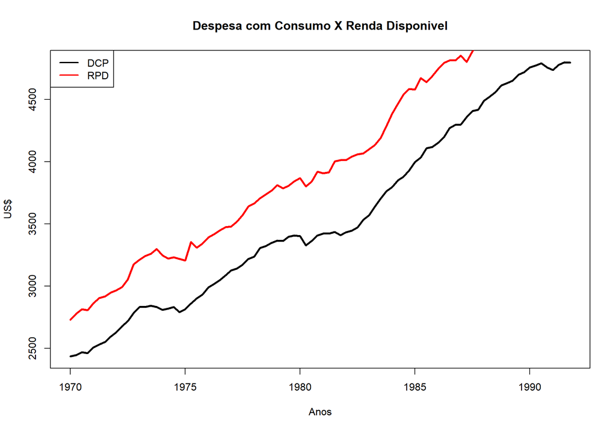

```r
#Graficos
plot(dcp, main='Despesa com Consumo X Renda Disponivel',
     xlab='Anos', ylab='US$', lwd=3)
lines(rpd, col='red', lwd=3)
legend('topleft', col=c('black','red'), lty=c(1,1), lwd=c(2,2),
       legend=c('DCP', 'RPD'))
```

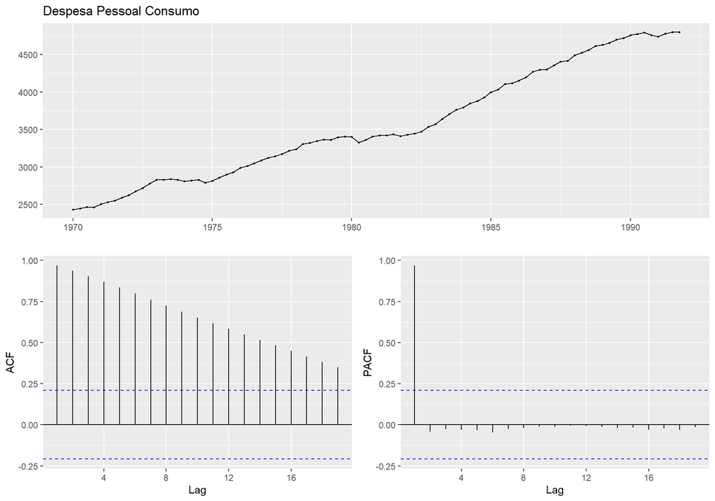

```r
#Correlograma das series
ggtsdisplay(dcp, main='Despesa Pessoal Consumo')
```

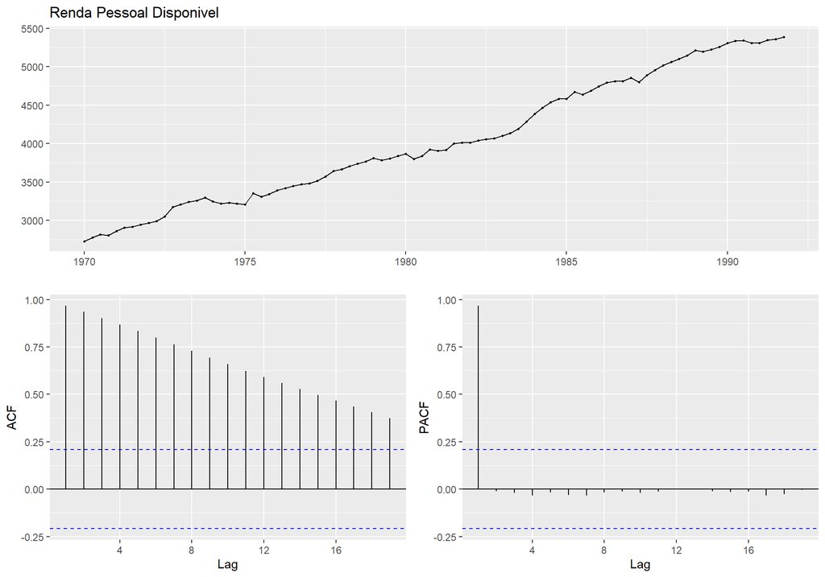

```r
ggtsdisplay(rpd, main='Renda Pessoal Disponivel')
```

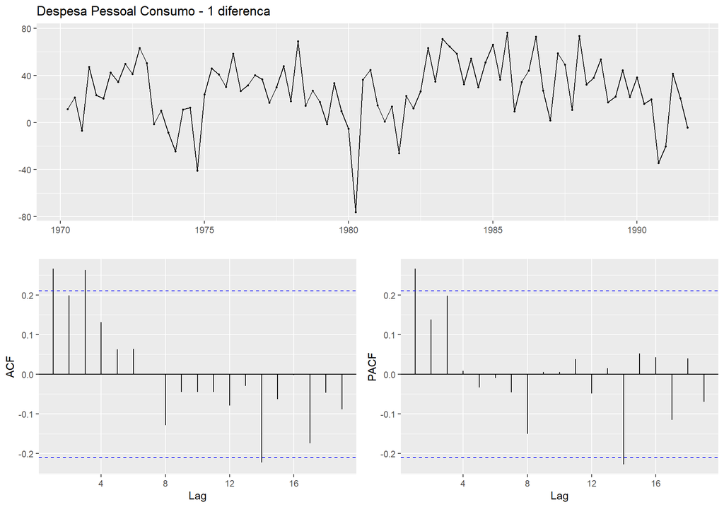

```r
#Diferenciacao da Serie
ddcp <- diff(dcp, differences = 1)
drpd <- diff(rpd, differences = 1)

#Visualizando Correlogramas na 1 Diferenca
ggtsdisplay(ddcp, main='Despesa Pessoal Consumo - 1 diferenca')
```

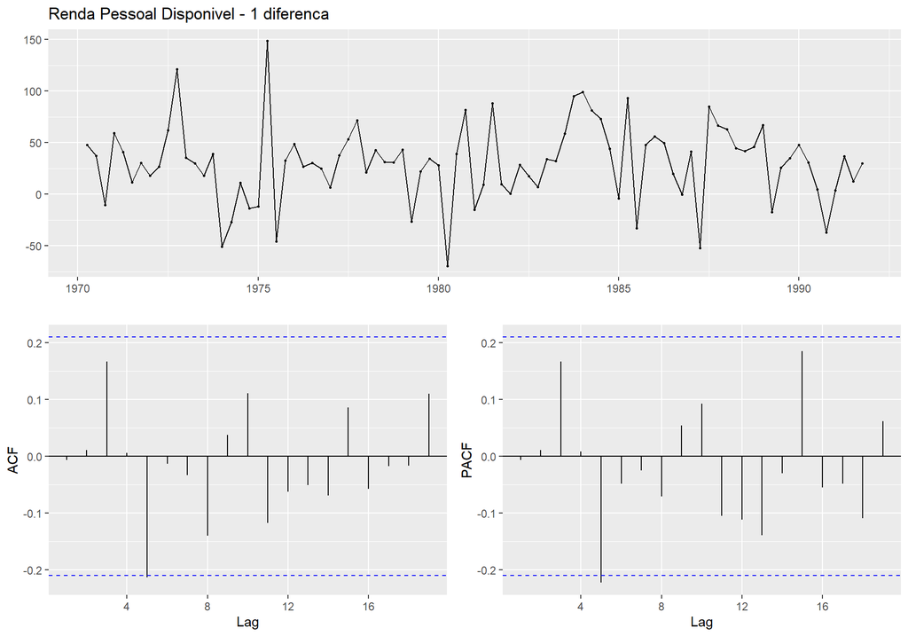

```r
ggtsdisplay(drpd, main='Renda Pessoal Disponivel - 1 diferenca')
```

## 1.3 Teste de Raiz Unitária DFGLS

O resultado do teste DF-GLS, em nível, com constante e tendência é:

```r
#Analise dos testes de raiz unitaria em nivel
#Definicao do numero maximo de lags
print(12*(length(dcp)/100)^(1/4))
```

```
# [1] 11.62256
```

```r
print(12*(length(rpd)/100)^(1/4))
```

```
# [1] 11.62256
```

```r
#Estatistica de Teste DFGLS para DCP
dcpT.dfgls <- ur.ers(dcp, type = c("DF-GLS"),
                      model = c("trend"),
                      lag.max = 3)
summary(dcpT.dfgls)
```

```
#
# ###############################################
# # Elliot, Rothenberg and Stock Unit Root Test #
# ###############################################
#
# Test of type DF-GLS
# detrending of series with intercept and trend
#
#
# Call:
# lm(formula = dfgls.form, data = data.dfgls)
#
# Residuals:
#     Min      1Q  Median      3Q     Max
# -99.721 -16.104   1.757  17.444  46.794
#
# Coefficients:
#              Estimate Std. Error t value Pr(>|t|)
# yd.lag       -0.04708    0.02376  -1.981   0.0510 .
# yd.diff.lag1  0.21198    0.10710   1.979   0.0512 .
# yd.diff.lag2  0.10992    0.10934   1.005   0.3178
# yd.diff.lag3  0.23985    0.10869   2.207   0.0302 *
# ---
# Signif. codes:  0 '***' 0.001 '**' 0.01 '*' 0.05 '.' 0.1 ' ' 1
#
# Residual standard error: 25.48 on 80 degrees of freedom
# Multiple R-squared:  0.166,   Adjusted R-squared:  0.1243
# F-statistic:  3.98 on 4 and 80 DF,  p-value: 0.005374
#
#
# Value of test-statistic is: -1.9814
#
# Critical values of DF-GLS are:
#                  1pct  5pct 10pct
# critical values -3.58 -3.03 -2.74
```

```r
#Estatistica de Teste DFGLS para RPD
rpdT.dfgls <- ur.ers(rpd, type = c("DF-GLS"),
                       model = c("trend"),
                       lag.max = 3)
summary(rpdT.dfgls)
```

```
#
# ###############################################
# # Elliot, Rothenberg and Stock Unit Root Test #
# ###############################################
#
# Test of type DF-GLS
# detrending of series with intercept and trend
#
#
# Call:
# lm(formula = dfgls.form, data = data.dfgls)
#
# Residuals:
#      Min       1Q   Median       3Q      Max
# -105.348  -20.803   -0.759   18.522  115.475
#
# Coefficients:
#              Estimate Std. Error t value Pr(>|t|)
# yd.lag       -0.09755    0.04342  -2.247   0.0274 *
# yd.diff.lag1  0.04094    0.10826   0.378   0.7063
# yd.diff.lag2  0.06605    0.10842   0.609   0.5441
# yd.diff.lag3  0.21608    0.10837   1.994   0.0496 *
# ---
# Signif. codes:  0 '***' 0.001 '**' 0.01 '*' 0.05 '.' 0.1 ' ' 1
#
# Residual standard error: 37.21 on 80 degrees of freedom
# Multiple R-squared:  0.08627, Adjusted R-squared:  0.04059
# F-statistic: 1.888 on 4 and 80 DF,  p-value: 0.1205
#
#
# Value of test-statistic is: -2.2466
#
# Critical values of DF-GLS are:
#                  1pct  5pct 10pct
# critical values -3.58 -3.03 -2.74
```

```r
#Estatistica de Teste DFGLS para DCP na 1 Diferença

#Diferenciacao da Serie
ddcp <- diff(dcp, differences = 1)
drpd <- diff(rpd, differences = 1)

ddcpT.dfgls <- ur.ers(ddcp, type = c("DF-GLS"),
                     model = c("constant"),
                     lag.max = 3)
summary(ddcpT.dfgls)
```

```
#
# ###############################################
# # Elliot, Rothenberg and Stock Unit Root Test #
# ###############################################
#
# Test of type DF-GLS
# detrending of series with intercept
#
#
# Call:
# lm(formula = dfgls.form, data = data.dfgls)
#
# Residuals:
#     Min      1Q  Median      3Q     Max
# -89.215 -12.393   6.036  20.737  46.652
#
# Coefficients:
#              Estimate Std. Error t value Pr(>|t|)
# yd.lag       -0.35239    0.13562  -2.598  0.01117 *
# yd.diff.lag1 -0.39330    0.14646  -2.685  0.00882 **
# yd.diff.lag2 -0.27885    0.13651  -2.043  0.04442 *
# yd.diff.lag3 -0.04225    0.11310  -0.374  0.70977
# ---
# Signif. codes:  0 '***' 0.001 '**' 0.01 '*' 0.05 '.' 0.1 ' ' 1
#
# Residual standard error: 26.44 on 79 degrees of freedom
# Multiple R-squared:  0.3759,  Adjusted R-squared:  0.3443
# F-statistic: 11.89 on 4 and 79 DF,  p-value: 1.298e-07
#
#
# Value of test-statistic is: -2.5984
#
# Critical values of DF-GLS are:
#                  1pct  5pct 10pct
# critical values -2.59 -1.94 -1.62
```

```r
#Estatistica de Teste DFGLS para RPD na 1 Diferença
drpdT.dfgls <- ur.ers(drpd, type = c("DF-GLS"),
                     model = c("constant"),
                     lag.max = 3)
summary(drpdT.dfgls)
```

```
#
# ###############################################
# # Elliot, Rothenberg and Stock Unit Root Test #
# ###############################################
#
# Test of type DF-GLS
# detrending of series with intercept
#
#
# Call:
# lm(formula = dfgls.form, data = data.dfgls)
#
# Residuals:
#      Min       1Q   Median       3Q      Max
# -102.328  -21.782   -6.494   10.478  122.894
#
# Coefficients:
#              Estimate Std. Error t value Pr(>|t|)
# yd.lag        -0.6413     0.1927  -3.328  0.00133 **
# yd.diff.lag1  -0.3187     0.1806  -1.765  0.08149 .
# yd.diff.lag2  -0.2550     0.1530  -1.666  0.09967 .
# yd.diff.lag3  -0.0447     0.1119  -0.399  0.69066
# ---
# Signif. codes:  0 '***' 0.001 '**' 0.01 '*' 0.05 '.' 0.1 ' ' 1
#
# Residual standard error: 39.27 on 79 degrees of freedom
# Multiple R-squared:  0.4935,  Adjusted R-squared:  0.4679
# F-statistic: 19.25 on 4 and 79 DF,  p-value: 4.377e-11
#
#
# Value of test-statistic is: -3.3283
#
# Critical values of DF-GLS are:
#                  1pct  5pct 10pct
# critical values -2.59 -1.94 -1.62
```

As duas séries possuem raiz unitária em nível, mas são estacionárias na primeira diferença, ou seja, são I(1). Então, as duas séries são integradas de mesma ordem. Se a combinação linear entre as duas for estacionário, elas serão cointegradas. Isto significa que existe uma relação de longo prazo entre elas. Considere a estimação de um modelo de despesas com consumo (DCP) em função da renda pessoal disponível (RPD):

$$DCP_t=\beta_0+\beta_1RPD_t+u_t$$

em que o $u_t$ é o termo de erro.

Resultado da regressão estimada:

```r
#Estimacao do Modelo DCP em funcao da RPD
regressao1 <- lm(dcp ~ rpd)
summary(regressao1)
```

```
#
# Call:
# lm(formula = dcp ~ rpd)
#
# Residuals:
#     Min      1Q  Median      3Q     Max
# -136.42  -23.16   10.82   33.77  103.39
#
# Coefficients:
#               Estimate Std. Error t value Pr(>|t|)
# (Intercept) -1.073e+02  2.841e+01  -3.777 0.000291 ***
# rpd          9.082e-01  6.898e-03 131.663  < 2e-16 ***
# ---
# Signif. codes:  0 '***' 0.001 '**' 0.01 '*' 0.05 '.' 0.1 ' ' 1
#
# Residual standard error: 52.05 on 86 degrees of freedom
# Multiple R-squared:  0.9951,  Adjusted R-squared:  0.995
# F-statistic: 1.734e+04 on 1 and 86 DF,  p-value: < 2.2e-16
```

A interpretação de RPD é como uma propensão marginal a consumir de longo prazo. Os resíduos desta regressão podem ser submetidos a um teste de raiz unitária.

## 1.4 Análise dos resíduos

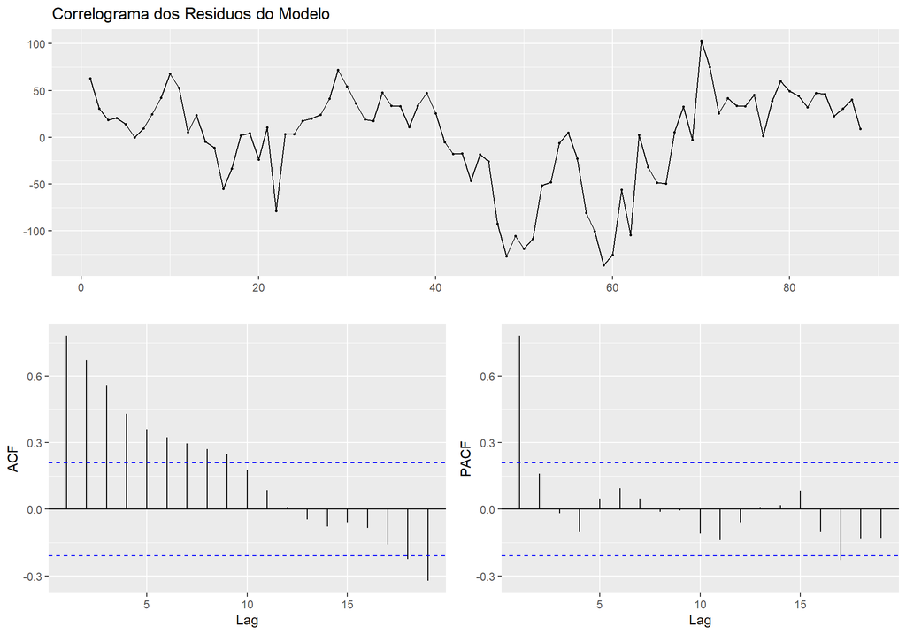

```r
#Salvando os residuos da regressao
resid1 <- regressao1$residuals

ggtsdisplay(resid1, main='Correlograma dos Residuos do Modelo')
```

```r
#Teste de raiz unitaria nos residuos
#Definicao do numero maximo de lags
print(12*(length(resid1)/100)^(1/4))
```

```
# [1] 11.62256
```

```r
resid.dfgls <- ur.ers(resid1, type = c("DF-GLS"),
                      model = c("constant"),
                      lag.max = 1)
summary(resid.dfgls)
```

```
#
# ###############################################
# # Elliot, Rothenberg and Stock Unit Root Test #
# ###############################################
#
# Test of type DF-GLS
# detrending of series with intercept
#
#
# Call:
# lm(formula = dfgls.form, data = data.dfgls)
#
# Residuals:
#     Min      1Q  Median      3Q     Max
# -85.632 -22.862  -4.317  13.124  94.918
#
# Coefficients:
#              Estimate Std. Error t value Pr(>|t|)
# yd.lag       -0.10854    0.05579  -1.946   0.0550 .
# yd.diff.lag1 -0.19342    0.10703  -1.807   0.0743 .
# ---
# Signif. codes:  0 '***' 0.001 '**' 0.01 '*' 0.05 '.' 0.1 ' ' 1
#
# Residual standard error: 32.21 on 84 degrees of freedom
# Multiple R-squared:  0.1017,  Adjusted R-squared:  0.08031
# F-statistic: 4.755 on 2 and 84 DF,  p-value: 0.01106
#
#
# Value of test-statistic is: -1.9456
#
# Critical values of DF-GLS are:
#                  1pct  5pct 10pct
# critical values -2.59 -1.94 -1.62
```

Os resíduos da regressão são estacionários, ou seja, I(0), considerando um nível de significância de 5%. Então, apesar das séries apresentarem tendencias estocásticas, a combinação linear delas (resíduo) é I(0).

O resultado disto é que a regressão passa a ter sentido e dizemos que as duas variáveis são co-integradas, ou seja, existe entre elas uma relação de equilíbrio de longo prazo.

No curto prazo, contudo, pode haver desequilíbrio Assim, o termo de erro u, obtido da estimativa, pode ser usado para relacionar o comportamento de curto prazo e o do longo prazo. Isto é chamado de **mecanismo de correção de erro**.

Considere o seguinte modelo:

$$\Delta{DCP_t}=\alpha_0+\alpha_1 \Delta{RPD_t}+\alpha_2u_{t-1}+\epsilon_t$$
$\Delta$ indica o operador de diferença; $\epsilon$ um termo de erro aleatório e $u_{t-1}$ é o valor defasado de um período do resíduo da regressão co-integrante.

A equação do mecanismo de correção de erro acima mostra que $\Delta{DCP_t}$ depende de $\Delta{RPD_t}$ e também do termo de erro de equilíbrio;

A estimativa da equação do mecanismo de correção de erro é:

## 1.5 Estimação do Mecanismo de Correção de Erro no R

```r
#Estimacao do modelo de Correcao de erro
regressao2 <- lm(ddcp ~ drpd + lag(resid1,-1)[-length(dcp)])
summary(regressao2)
```

```
#
# Call:
# lm(formula = ddcp ~ drpd + lag(resid1, -1)[-length(dcp)])
#
# Residuals:
#     Min      1Q  Median      3Q     Max
# -69.730 -15.068   0.559  13.273  59.347
#
# Coefficients:
#                               Estimate Std. Error t value Pr(>|t|)
# (Intercept)                   16.74907    3.36630   4.976 3.41e-06 ***
# drpd                           0.33955    0.07042   4.822 6.26e-06 ***
# lag(resid1, -1)[-length(dcp)] -0.12906    0.05122  -2.520   0.0136 *
# ---
# Signif. codes:  0 '***' 0.001 '**' 0.01 '*' 0.05 '.' 0.1 ' ' 1
#
# Residual standard error: 24.13 on 84 degrees of freedom
# Multiple R-squared:  0.2331,  Adjusted R-squared:  0.2148
# F-statistic: 12.76 on 2 and 84 DF,  p-value: 1.444e-05
```

Como pode ser observado, a estimativa de u(-1) é negativo. Isto significa que DCP está acima do equilíbrio e começará a cair no período seguinte para retornar ao equilíbrio. A interpretação é que 12,91 % da discrepância entre as duas variáveis no trimestre anterior é eliminado no trimestre atual.

A interpretação de D(RPD) é como uma propensão marginal a consumir de curto prazo.